# Manipulação de Dados - JSON

Elizabeth Borgognoni Souto

September 5, 2018

# Instalação de pacotes essenciais

Os pacotes que são essenciais para a execução deste laboratório podem ser instalados de acordo com o snippet abaixo. Execute esta instalação antes de tentar criar um novo documento RMarkdown. Se o sistema perguntar sobre instalar novos pacotes a partir do código-fonte (install newer version from source), responda n (para indicar não).

```r
#no caso nao coloquei win.binary pois estou trabalhando no Rstudio do ubuntu
options(install.packages.check.source = "no")
pkgs = c('tidyverse', 'maps', 'RColorBrewer',
         'rmarkdown', 'knitr', 'caTools', 'tidyr',
         'jsonlite', 'dplyr', 'tibble', 'digest',
         'magrittr', 'lubridate')
install.packages(pkgs)
```

```r
#carregando os pacotes
library("tidyverse")
library("maps")
library("RColorBrewer")
library("rmarkdown")
library("knitr")
library("caTools")
library("tidyr")
library("jsonlite")
library("dplyr")
library("tibble")
library("digest")
library("magrittr")
library("lubridate")
```

# Arquivos JSON

JavaScript Object Notation é um formato amplamente utilizado, principalmente em recursos de internet, para armazenar informações em um modo que seja relativamente fácil de acessar. O foco desta estratégia de armazenamento é prover mecanismos simples para busca de dados. Um registro JSON é sempre apresentado dentro de chaves e representado por uma coleção de pares chave/valor. Cada um destes pares é apresentado sempre da seguinte maneira ‘chave’: ‘valor’. Múltiplos pares são sempre separados por vírgula. Um exemplo de registro é:

```json
#campos separados por virgula
{
  "nome": "Benilton",
  "sobrenome": "Carvalho",
  "escolaridade": "Ph.D.",
  "orientador": "Rafael Irizarry",
  "area": "Bioestatistica",
  "universidade": "Johns Hopkins University",
  "ano": "2008"
}
```

Múltiplos registros JSON podem ser combinados em um único objeto com o uso de colchetes delimitando o objeto resultante e vírgulas, separando cada um dos registros. Por exemplo:

```json
[{
  "nome": "Benilton",
  "sobrenome": "Carvalho",
  "escolaridade": "Ph.D.",
  "orientador": "Rafael Irizarry",
  "area": "Bioestatistica",
  "universidade": "Johns Hopkins University",
  "ano": "2008"
},

{
  "nome": "Guilherme",
  "sobrenome": "Ludwig",
  "escolaridade": "Ph.D.",
  "orientador:" "Jun Zhu",
  "area": "Estatistica",
  "universidade": "University of Wisconsin-Madison",
  "ano": "2016"
}]
```

# Manipulação de Objetos JSON em R

O pacote jsonlite pode ser utilizado para a manipulação de objetos JSON. O comando fromJSON recebe uma entrada em formato JSON e a converte para um objeto apropriado em R (vetor, matriz ou data.frame). O comando toJSON trabalha na direção oposta, recebendo um objeto em R e convertendo-o para JSON.

A leitura de um arquivo JSON pode ser feita utilizando o comando read_json deste mesmo pacote jsonlite. O comando read_json possui um segundo argumento chamado simplifyVector, que assume o valor FALSE por padrão. O argumento simplifyVector=FALSE causa com que o objeto resultante seja uma lista; com simplifyVector=TRUE, o resultado é convertido para um objeto R mais apropriado (data.frame).

# Descrição dos Dados

Uma start-up norte-americana disponibilizou uma plataforma de crowdsourcing para plataformas móveis iOS e Android. Usuários, após um cadastro inicial, podem visitar páginas de projetos e escolher contribuir com um valor monetário. Estes eventos de visita e contribuição financeira são registradas no campo `event_name`, do arquivo `data.json` disponibilizado, como View Project e Fund Project. O arquivo também disponibiliza informações dadas durante o cadastro:

- gender: sexo - F (female), M (male), U (unknown);
- age: idade - 18-24, 25-34, 35-44, 45-54 ou 55+;
- marital_status: estado civil - single ou married;
- device: iOS ou android
- latitude: latitude
- longitude: longitude
- city: cidade
- state: estado
- zip_code: CEP

Para os 50 mil registros disponibilizados, informam-se também a categoria (category) do projeto visitado/financiado, a quantia doada (amount) quando o usuário decidiu financiar o projeto e a data/hora (formato UNIX a partir de 01 de janeiro de 1970) no fuso-horário GMT.

# Atividade

Você deve apresentar um relatório técnico-gerencial (isto é, deve conter texto claro, gramaticalmente e ortograficamente correto combinado com código em R) que responda às seguintes questões:

```r
#as viariaveis acima sao estaticas e fazem parte das caracteristicas dos usuarios
#importando o arquivo e manipulando os dados
setwd("/home/elizabeth/Downloads/data.json")
data_json = read_json("data.json", simplifyVector = TRUE)
data_json = data_json$data #faco isso pois e uma lista
dim(data_json) #para analisar a dimensao do data frame
```

```
## [1] 50000    10
```

```r
str(data_json) #para analisar a estrutura do data frame
```

```
## 'data.frame':    50000 obs. of  10 variables:
##  $ category      : chr  "Sports" "Technology" "Environment" "Technology" ...
##  $ event_name    : chr  "View Project" "View Project" "View Project" "View Project" ...
##  $ gender        : chr  "M" "M" "M" "M" ...
##  $ age           : chr  "18-24" "18-24" "55+" "18-24" ...
##  $ marital_status: chr  "married" "single" "single" "single" ...
##  $ session_id    : chr  "69f62d2ae87640f5a2dde2b2e9229fe6" "4459d001feb8438eae5f4ec24abcd992" "0db9ed700a184d48a9d04806696e3642" "68195e2372bd4022b17220fc21de9138" ...
##  $ device        : chr  "android" "iOS" "iOS" "android" ...
##  $ client_time   : int  1393632004 1393632022 1393632032 1393632038 1393632051 1393632064 1393632137 1393632138 1393632145 1393632159 ...
##  $ location      :'data.frame':  50000 obs. of  5 variables:
##   ..$ latitude : num  40.2 33.8 42.4 44.6 36.7 ...
##   ..$ city     : chr  "Lyons" "Alpharetta" "Westford" "Saranac" ...
##   ..$ state    : chr  "CO" "GA" "MA" "NY" ...
##   ..$ longitude: num  -105.4 -84.5 -71.5 -73.8 -93.5 ...
##   ..$ zip_code : chr  "80540" "30009" "01886" "12981" ...
##  $ amount        : int  NA NA NA NA NA NA NA NA NA NA ...
```

```r
#a coluna 9 e o outro dataframe  (em json podemos ter um dataframe dentro de outro)
data_json = cbind(data_json[,-9], data_json[,9])
dim(data_json)
```

```
## [1] 50000    14
```

```r
#transformando em tibble
data_json = as_tibble(data_json)
```

- Quantos usuários diferentes utilizaram a plataforma no período coletado?

```r
#para descobrir quantos usuarios diferentes temos que criar uma chave usando todas as variavies estaticas
#client_time numero de segundos , momento que ele acessou a rede
user = data_json %>%
  select(gender,age,marital_status,device,latitude,longitude,city,state,zip_code) %>%
  distinct()  #da os valores que sao distintos um do outro como o comando unique

user$user_id = 1:nrow(user) #da linha 1 ate a ultima linha
data_json = data_json %>% inner_join(user) #para juntar ambas as chaves estaticas
```

Em `data_json` se 2 pessoas estiverem morando na mesma casa e usarem o mesmo computador sera identificado como a mesma pessoa. A quantidade de usuários diferentes que utilizaram a plataforma foram 9164.

- Qual é a distribuição de perfis dos usuário de acordo com as variáveis gender, age, marital_status e device? Apresente uma tabela com contagens de usuários em cada classe. A tabela final deve ter as seguintes colunas: gender, marital_status, device, 18-24, 25-34, 45-54, 55+. Insira a tabela no texto utilizando o comando knitr::kable.

```r
data_json1 = data_json %>%
  select(gender, age, marital_status, device, user_id) %>%
  distinct() %>% #para pegar os identificadores
  select(-user_id) %>% #para remover user_id
  group_by(gender, age, marital_status, device) %>%
  count() %>% #ou uso summarise com a funcao n()
  spread(age, n) #abre o que estiver em age
```

```r
#knitr::kable p mostrar a tabela
knitr::kable(data_json1)
```

| gender | marital_status | device | 18-24 | 25-34 | 35-44 | 45-54 | 55+ |
| --- | --- | --- | --- | --- | --- | --- | --- |
| F | married | android | 187 | 122 | 128 | 149 | 137 |
| F | married | iOS | 336 | 251 | 283 | 270 | 298 |
| F | single | android | 189 | 147 | 136 | 134 | 114 |
| F | single | iOS | 189 | 146 | 151 | 156 | 134 |
| M | married | android | 178 | 130 | 135 | 121 | 118 |
| M | married | iOS | 322 | 281 | 278 | 253 | 270 |
| M | single | android | 185 | 120 | 151 | 133 | 146 |
| M | single | iOS | 183 | 149 | 150 | 144 | 145 |
| U | married | android | 107 | 61 | 68 | 57 | 66 |
| U | married | iOS | 195 | 154 | 156 | 160 | 172 |
| U | single | android | 105 | 59 | 64 | 67 | 64 |
| U | single | iOS | 98 | 54 | 77 | 61 | 70 |

- Existe a suspeita de que o número de indivíduos que utilizam iOS é maior que o número de usuários de Android nos grupos de pessoas casadas. Apresente um gráfico, utilizando ggplot2, que mostre se esta suspeita é plausível. O gráfico deve incluir as informações de sexo, idade e estado civil.

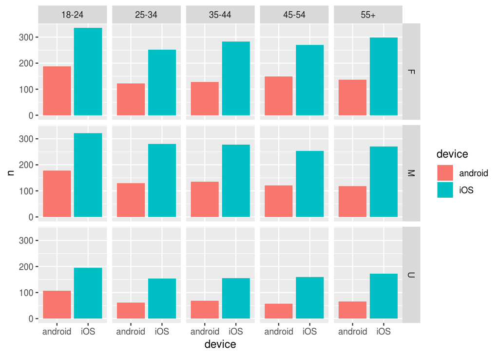

```r
data_json2 = data_json %>%
  select(gender, age, marital_status, device, user_id) %>%
  distinct() %>%
  group_by(gender, age, marital_status, device) %>%
  count()

ggplot(data_json2 %>% filter(marital_status == "married"), aes(device, n, fill = device)) +
         geom_bar(stat="identity") + facet_grid(gender ~ age)
```

```r
#distribuicao dos usuarios onde eles moram em termo de estado
data_json3 = data_json %>%
  select(state, user_id) %>%
  distinct() %>%
  group_by(state) %>%
  count() %>%
  ungroup() %>% #para desagrupar
  top_n(1) #para selecionar as observacoes por estado que tem o maior numero de usuarios
```

- Para cada nível de category, considere apenas os usuários únicos que viram ou financiaram projetos daquela categoria. Agrupe estes usuários por sexo, idade, estado civil e dispositivo. Para cada um destes grupos, qual é o percentual de financiamento dos projetos? Apresente o resultado em uma tabela com as seguintes colunas: category, gender, marital_status, device, 18-24, 25-34, 35-44, 45-54 e 55+.

```r
data_json_final = data_json %>%
  #pego o amount que e a quantidade de dinheiro que ele financiou
  mutate(finance = !is.na(amount)) %>%
  select(category, gender, age, marital_status, device, user_id, finance) %>%
  group_by(category,user_id,gender,marital_status,device,age) %>%
  summarise(decision = any(finance)) %>%
  group_by(category, gender, marital_status, device, age) %>%
  summarise(Perc_Finan = mean(decision)) %>%
  spread(age, Perc_Finan)
```

- Exporte todas as tabelas criadas para arquivos CSV.

```r
write_csv(data_json, path = "data_json_final.csv")
write_csv(data_json1, path = "data_json_final1.csv")
write_csv(data_json2, path = "data_json_final2.csv")
write_csv(data_json3, path = "data_json_final3.csv")
write_csv(data_json_final, path = "data_json_final4.csv")
```